# 16-kdm6b-myeloid-transcriptional-comparison

Bicna Song

2026-08-13

This analysis compares the transcriptional profiles of Kdm6b-high and Kdm6b-low myeloid subclusters. Intermediate subclusters are excluded from the comparison.

Raw RNA counts are aggregated into one Kdm6b-high and one Kdm6b-low pseudobulk profile per biological sample. The paired DESeq2 design, `~ sample + kdm6b_group`, estimates the high-versus-low difference within samples and then combines that evidence across all samples. Treatment is not included as a tested effect.

## Setup

```r
suppressPackageStartupMessages({
  library(rprojroot)
  library(dplyr)
  library(tidyr)
  library(tibble)
  library(ggplot2)
  library(SeuratObject)
  library(Matrix)
  library(DESeq2)
  library(msigdbr)
  library(fgsea)
  library(ComplexHeatmap)
})

root_dir <- find_root(has_dir(".git"))
data_dir <- file.path(root_dir, "data", "v5")
analysis_dir <- file.path(root_dir, "analyses", "downstream-analyses")
results_dir <- file.path(analysis_dir, "results", "myeloid", "kdm6b")
plot_dir <- file.path(analysis_dir, "plots", "myeloid", "kdm6b")

dir.create(results_dir, recursive = TRUE, showWarnings = FALSE)
dir.create(plot_dir, recursive = TRUE, showWarnings = FALSE)

source(file.path(root_dir, "figures", "theme.R"))
set.seed(1234)
```

## Analysis parameters

```r
input_file <- file.path(data_dir, params$input_rds)
ranking_file <- file.path(results_dir, params$ranking_tsv)
min_total_count <- params$min_total_count
de_fdr <- params$de_fdr
heatmap_genes_per_direction <- params$heatmap_genes_per_direction
gsea_min_size <- params$gsea_min_size
gsea_max_size <- params$gsea_max_size
gsea_pathways_per_direction <- params$gsea_pathways_per_direction

kdm6b_group_levels <- c("Kdm6b-low", "Kdm6b-high")
condition_levels <- c(
  "41BB-L", "B7H3", "CD28-41BB", "CD8-41BB", "STOP", "tumor"
)
kdm6b_group_colors <- c(
  "Kdm6b-low" = "#2166AC",
  "Kdm6b-high" = "#B2182B"
)
missing_input_files <- c(input_file, ranking_file)[
  !file.exists(c(input_file, ranking_file))
]
if (length(missing_input_files) > 0) {
  stop("Missing input file(s): ", paste(missing_input_files, collapse = ", "))
}
```

## Load data and map Kdm6b groups

The previously defined high and low assignments are imported from the subcluster-ranking table and are not recalculated here.

```r
myeloid_obj <- readRDS(input_file)
kdm6b_ranking <- readr::read_tsv(ranking_file, show_col_types = FALSE) %>%
  dplyr::mutate(subcluster = as.character(subcluster))

required_metadata <- c("sample", "condition", "seurat_clusters")
required_ranking_columns <- c("subcluster", "kdm6b_group")
stopifnot(all(required_metadata %in% colnames(myeloid_obj@meta.data)))
stopifnot(all(required_ranking_columns %in% colnames(kdm6b_ranking)))

if (anyDuplicated(kdm6b_ranking$subcluster)) {
  stop("Each numeric subcluster must have exactly one Kdm6b group assignment.")
}

observed_subclusters <- unique(as.character(myeloid_obj$seurat_clusters))
if (!setequal(observed_subclusters, kdm6b_ranking$subcluster)) {
  stop("The ranking table and myeloid object contain different subclusters.")
}

cell_metadata <- myeloid_obj@meta.data %>%
  tibble::rownames_to_column("cell") %>%
  dplyr::transmute(
    cell,
    sample = as.character(sample),
    condition = as.character(condition),
    subcluster = as.character(seurat_clusters)
  ) %>%
  dplyr::left_join(
    kdm6b_ranking %>% dplyr::select(subcluster, kdm6b_group),
    by = "subcluster"
  )

if (anyNA(cell_metadata$kdm6b_group)) {
  stop("At least one myeloid cell could not be assigned to a Kdm6b group.")
}

analysis_metadata <- cell_metadata %>%
  dplyr::filter(kdm6b_group %in% kdm6b_group_levels) %>%
  dplyr::mutate(
    condition = factor(condition, levels = condition_levels),
    kdm6b_group = factor(kdm6b_group, levels = kdm6b_group_levels),
    profile_id = paste(sample, kdm6b_group, sep = "__")
  )

if (anyNA(analysis_metadata$condition)) {
  stop("At least one cell has a condition outside condition_levels.")
}

cat("Cells retained for the high-versus-low comparison:",
    nrow(analysis_metadata), "\n")
```

```
## Cells retained for the high-versus-low comparison: 50650
```

```r
cat("Intermediate cells excluded:",
    nrow(cell_metadata) - nrow(analysis_metadata), "\n")
```

```
## Intermediate cells excluded: 53181
```

```r
table(analysis_metadata$kdm6b_group, analysis_metadata$condition)
```

```
##
##              41BB-L B7H3 CD28-41BB CD8-41BB STOP tumor
##   Kdm6b-low    3302 3496      5476     3809 2869  2825
##   Kdm6b-high   4763 4555      6338     5449 4184  3584
```

## Build paired sample-level pseudobulks

Each sample must contribute both a Kdm6b-high and a Kdm6b-low profile. Raw RNA counts are summed across all cells belonging to each sample and group.

```r
counts <- SeuratObject::GetAssayData(
  myeloid_obj,
  assay = "RNA",
  layer = "counts"
)

if (!all(analysis_metadata$cell %in% colnames(counts))) {
  stop("At least one retained cell is absent from the RNA count matrix.")
}

analysis_metadata <- analysis_metadata %>%
  dplyr::arrange(match(cell, colnames(counts)))
analysis_counts <- counts[, analysis_metadata$cell, drop = FALSE]
stopifnot(identical(colnames(analysis_counts), analysis_metadata$cell))

profile_metadata <- analysis_metadata %>%
  dplyr::count(
    profile_id,
    sample,
    condition,
    kdm6b_group,
    name = "n_cells"
  ) %>%
  dplyr::arrange(sample, kdm6b_group)

pair_check <- profile_metadata %>%
  dplyr::count(sample, name = "n_group_profiles")
if (any(pair_check$n_group_profiles != 2)) {
  stop("Every sample must contain one Kdm6b-high and one Kdm6b-low profile.")
}

profile_indicator <- Matrix::sparseMatrix(
  i = seq_len(ncol(analysis_counts)),
  j = match(analysis_metadata$profile_id, profile_metadata$profile_id),
  x = 1,
  dims = c(ncol(analysis_counts), nrow(profile_metadata)),
  dimnames = list(colnames(analysis_counts), profile_metadata$profile_id)
)
pseudobulk_counts <- analysis_counts %*% profile_indicator

profile_metadata <- profile_metadata %>%
  dplyr::mutate(
    raw_library_size = as.numeric(Matrix::colSums(pseudobulk_counts)),
    sample_number = sub("^.*_(D[0-9]+)$", "\\1", sample)
  )

profile_metadata
```

```
##                        profile_id             sample condition kdm6b_group
## 1      41BB-L_pos_T_D1__Kdm6b-low    41BB-L_pos_T_D1    41BB-L   Kdm6b-low
## 2     41BB-L_pos_T_D1__Kdm6b-high    41BB-L_pos_T_D1    41BB-L  Kdm6b-high
## 3      41BB-L_pos_T_D2__Kdm6b-low    41BB-L_pos_T_D2    41BB-L   Kdm6b-low
## 4     41BB-L_pos_T_D2__Kdm6b-high    41BB-L_pos_T_D2    41BB-L  Kdm6b-high
## 5        B7H3_pos_T_D1__Kdm6b-low      B7H3_pos_T_D1      B7H3   Kdm6b-low
## 6       B7H3_pos_T_D1__Kdm6b-high      B7H3_pos_T_D1      B7H3  Kdm6b-high
## 7        B7H3_pos_T_D2__Kdm6b-low      B7H3_pos_T_D2      B7H3   Kdm6b-low
## 8       B7H3_pos_T_D2__Kdm6b-high      B7H3_pos_T_D2      B7H3  Kdm6b-high
## 9   CD28-41BB_pos_T_D1__Kdm6b-low CD28-41BB_pos_T_D1 CD28-41BB   Kdm6b-low
## 10 CD28-41BB_pos_T_D1__Kdm6b-high CD28-41BB_pos_T_D1 CD28-41BB  Kdm6b-high
## 11  CD28-41BB_pos_T_D2__Kdm6b-low CD28-41BB_pos_T_D2 CD28-41BB   Kdm6b-low
## 12 CD28-41BB_pos_T_D2__Kdm6b-high CD28-41BB_pos_T_D2 CD28-41BB  Kdm6b-high
## 13   CD8-41BB_pos_T_D1__Kdm6b-low  CD8-41BB_pos_T_D1  CD8-41BB   Kdm6b-low
## 14  CD8-41BB_pos_T_D1__Kdm6b-high  CD8-41BB_pos_T_D1  CD8-41BB  Kdm6b-high
```

[output cut: 35 more lines]

## Paired differential-expression analysis

The sample term blocks differences among biological samples. The model tests one common Kdm6b-high versus Kdm6b-low effect across the 12 paired samples. Treatment is retained only as provenance in the profile table and is not included in the design, contrast, or plots.

Genes with fewer than 10 total counts across the 24 profiles are excluded before model fitting. The output table contains every gene tested by DESeq2, rather than only statistically significant genes.

```r
coldata <- profile_metadata %>%
  dplyr::mutate(
    sample_block = factor(match(sample, unique(sample))),
    kdm6b_group_model = factor(
      ifelse(kdm6b_group == "Kdm6b-high", "high", "low"),
      levels = c("low", "high")
    )
  ) %>%
  as.data.frame()
rownames(coldata) <- coldata$profile_id

pseudobulk_counts <- pseudobulk_counts[, rownames(coldata), drop = FALSE]
keep_genes <- Matrix::rowSums(pseudobulk_counts) >= min_total_count
cat("Genes retained for DESeq2:", sum(keep_genes), "of",
    length(keep_genes), "\n")
```

```
## Genes retained for DESeq2: 13056 of 19055
```

```r
design_matrix <- stats::model.matrix(
  ~ sample_block + kdm6b_group_model,
  data = coldata
)
if (qr(design_matrix)$rank != ncol(design_matrix)) {
  stop("The paired DESeq2 design matrix is not full rank.")
}

dds <- DESeq2::DESeqDataSetFromMatrix(
  countData = round(as.matrix(pseudobulk_counts[keep_genes, , drop = FALSE])),
  colData = coldata,
  design = ~ sample_block + kdm6b_group_model
)
dds <- DESeq2::DESeq(dds, quiet = TRUE)

de_result <- DESeq2::results(
  dds,
  contrast = c("kdm6b_group_model", "high", "low"),
  alpha = de_fdr
)

de_table <- as.data.frame(de_result) %>%
  tibble::rownames_to_column("gene") %>%
  dplyr::mutate(
    comparison = "Kdm6b-high vs Kdm6b-low",
    direction = dplyr::case_when(
      is.na(log2FoldChange) ~ NA_character_,
      log2FoldChange > 0 ~ "Higher in Kdm6b-high",
      log2FoldChange < 0 ~ "Higher in Kdm6b-low",
      TRUE ~ "No direction"
    ),
    significant_fdr = !is.na(padj) & padj < de_fdr
  ) %>%
  dplyr::arrange(is.na(padj), padj, pvalue)

readr::write_tsv(
  de_table,
  file.path(results_dir, "myeloid_kdm6b_high_vs_low_paired_deseq2.tsv")
)

summary(de_result)
```

```
##
## out of 13056 with nonzero total read count
## adjusted p-value < 0.05
## LFC > 0 (up)       : 3011, 23%
## LFC < 0 (down)     : 3213, 25%
## outliers [1]       : 0, 0%
## low counts [2]     : 1772, 14%
## (mean count < 1)
## [1] see 'cooksCutoff' argument of ?results
## [2] see 'independentFiltering' argument of ?results
```

```r
table(de_table$direction, de_table$significant_fdr, useNA = "ifany")
```

```
##
##                        FALSE TRUE
##   Higher in Kdm6b-high  3023 3011
##   Higher in Kdm6b-low   3809 3213
```

## Hallmark gene-set enrichment analysis

All genes with finite DESeq2 Wald statistics are ranked from higher in Kdm6b-high to higher in Kdm6b-low. Positive normalized enrichment scores indicate Hallmark pathways associated with the Kdm6b-high subclusters.

```r
hallmark_pathways <- msigdbr::msigdbr(
  species = "Mus musculus",
  collection = "H"
) %>%
  dplyr::select(gs_name, gene_symbol) %>%
  split(x = .$gene_symbol, f = .$gs_name)

gene_ranks <- de_table %>%
  dplyr::filter(!is.na(stat), is.finite(stat)) %>%
  dplyr::select(gene, stat) %>%
  tibble::deframe() %>%
  sort(decreasing = TRUE)

set.seed(1234)
hallmark_gsea <- fgsea::fgsea(
  pathways = hallmark_pathways,
  stats = gene_ranks,
  minSize = gsea_min_size,
  maxSize = gsea_max_size
) %>%
  dplyr::arrange(padj, pval) %>%
  dplyr::mutate(
    direction = ifelse(
      NES > 0,
      "Enriched in Kdm6b-high",
      "Enriched in Kdm6b-low"
    )
  )

hallmark_gsea_output <- hallmark_gsea %>%
  dplyr::mutate(
    leadingEdge = vapply(
      leadingEdge,
      paste,
      collapse = ";",
      FUN.VALUE = character(1)
    )
  )

readr::write_tsv(
  hallmark_gsea_output,
  file.path(results_dir, "myeloid_kdm6b_high_vs_low_hallmark_gsea.tsv")
)

hallmark_gsea_output
```

```
##                                        pathway         pval         padj
##                                         <char>        <num>        <num>
##  1:           HALLMARK_TNFA_SIGNALING_VIA_NFKB 9.932399e-38 4.966200e-36
##  2:         HALLMARK_OXIDATIVE_PHOSPHORYLATION 2.942086e-15 7.355215e-14
##  3:             HALLMARK_INFLAMMATORY_RESPONSE 3.310424e-11 5.517374e-10
##  4:                      HALLMARK_ADIPOGENESIS 3.415778e-09 3.743240e-08
##  5:               HALLMARK_ALLOGRAFT_REJECTION 3.743240e-09 3.743240e-08
##  6:         HALLMARK_INTERFERON_GAMMA_RESPONSE 3.240235e-08 2.700196e-07
##  7:                    HALLMARK_G2M_CHECKPOINT 4.854482e-07 3.467487e-06
##  8:               HALLMARK_IL2_STAT5_SIGNALING 1.515819e-06 9.473868e-06
##  9:           HALLMARK_IL6_JAK_STAT3_SIGNALING 3.833353e-06 2.129640e-05
## 10:             HALLMARK_FATTY_ACID_METABOLISM 5.722237e-06 2.861118e-05
## 11:                   HALLMARK_MITOTIC_SPINDLE 6.519229e-06 2.963286e-05
## 12:                HALLMARK_TGF_BETA_SIGNALING 2.912655e-05 1.213606e-04
## 13:                        HALLMARK_GLYCOLYSIS 6.809788e-05 2.619149e-04
```

[output cut: 197 more lines]

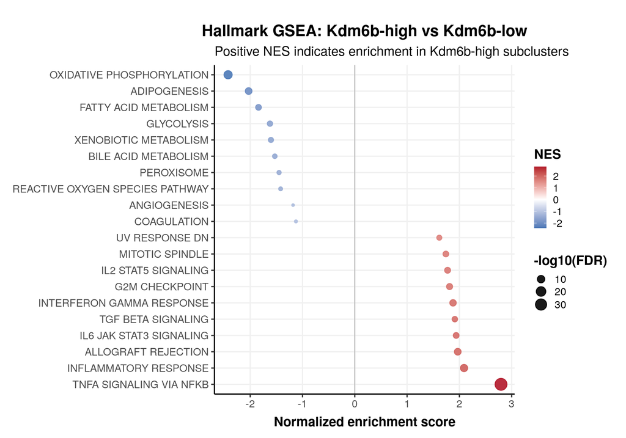

```r
gsea_plot_data <- hallmark_gsea %>%
  dplyr::filter(!is.na(padj), is.finite(padj), is.finite(NES)) %>%
  dplyr::group_by(direction) %>%
  dplyr::slice_min(order_by = padj, n = gsea_pathways_per_direction) %>%
  dplyr::ungroup() %>%
  dplyr::mutate(
    pathway_label = stringr::str_remove(pathway, "^HALLMARK_"),
    pathway_label = stringr::str_replace_all(pathway_label, "_", " "),
    pathway_label = factor(
      pathway_label,
      levels = rev(unique(pathway_label[order(NES)]))
    ),
    minus_log10_fdr = -log10(pmax(padj, .Machine$double.xmin))
  )

if (nrow(gsea_plot_data) == 0) {
  stop("No finite Hallmark GSEA results are available for plotting.")
}

p_hallmark_gsea <- ggplot(
  gsea_plot_data,
  aes(
    x = NES,
    y = pathway_label,
    color = NES,
    size = minus_log10_fdr
  )
) +
  geom_vline(xintercept = 0, color = "grey70", linewidth = 0.5) +
  geom_point(alpha = 0.9) +
  scale_color_gradient2(
    low = "#2166AC",
    mid = "white",
    high = "#B2182B",
    midpoint = 0
  ) +
  theme_Publication() +
  theme(
    panel.background = element_rect(fill = "white", color = NA),
    plot.background = element_rect(fill = "white", color = NA),
    legend.key = element_rect(fill = "white", color = NA)
  ) +
  labs(
    title = "Hallmark GSEA: Kdm6b-high vs Kdm6b-low",
    subtitle = "Positive NES indicates enrichment in Kdm6b-high subclusters",
    x = "Normalized enrichment score",
    y = NULL,
    color = "NES",
    size = "-log10(FDR)"
  )

p_hallmark_gsea
```

```r
ggsave(
  file.path(plot_dir, "myeloid_kdm6b_high_vs_low_hallmark_gsea_dotplot.pdf"),
  plot = p_hallmark_gsea,
  width = 10,
  height = 7,
  device = cairo_pdf,
  bg = "white"
)
```

## Heatmap of top differential genes

The heatmap displays variance-stabilized pseudobulk expression. Genes are ranked separately by direction, prioritizing FDR-significant genes. If fewer than the requested number pass the FDR threshold, the remaining positions are filled by the next best-ranked tested genes and identified in the accompanying table. Columns are ordered with all Kdm6b-high profiles first, followed by all Kdm6b-low profiles; individual sample labels are hidden.

```r
heatmap_gene_table <- de_table %>%
  dplyr::filter(
    direction %in% c("Higher in Kdm6b-high", "Higher in Kdm6b-low"),
    !is.na(pvalue),
    is.finite(pvalue),
    is.finite(log2FoldChange)
  ) %>%
  dplyr::group_by(direction) %>%
  dplyr::arrange(
    dplyr::desc(significant_fdr),
    padj,
    pvalue,
    dplyr::desc(abs(log2FoldChange)),
    .by_group = TRUE
  ) %>%
  dplyr::slice_head(n = heatmap_genes_per_direction) %>%
  dplyr::ungroup() %>%
  dplyr::mutate(
    heatmap_direction = factor(
      direction,
      levels = c("Higher in Kdm6b-high", "Higher in Kdm6b-low")
    )
  ) %>%
  dplyr::arrange(heatmap_direction, padj, pvalue)

if (nrow(heatmap_gene_table) == 0) {
  stop("No genes are available for the differential-expression heatmap.")
}

readr::write_tsv(
  heatmap_gene_table,
  file.path(results_dir, "myeloid_kdm6b_high_vs_low_heatmap_genes.tsv")
)

heatmap_gene_table %>%
  dplyr::select(
    gene,
    log2FoldChange,
    padj,
    significant_fdr,
    direction
  )
```

```
## # A tibble: 50 × 5
##    gene     log2FoldChange      padj significant_fdr direction
##    <chr>             <dbl>     <dbl> <lgl>           <chr>
##  1 Mideas             2.45 1.58e-135 TRUE            Higher in Kdm6b-high
##  2 Egr3               4.08 1.24e-115 TRUE            Higher in Kdm6b-high
##  3 Itpkc              2.88 1.52e-115 TRUE            Higher in Kdm6b-high
##  4 Btaf1              1.72 1.82e-108 TRUE            Higher in Kdm6b-high
##  5 Csf1               3.11 5.09e-107 TRUE            Higher in Kdm6b-high
##  6 Dennd4a            3.50 1.09e-102 TRUE            Higher in Kdm6b-high
##  7 Rbm39              1.00 1.14e- 97 TRUE            Higher in Kdm6b-high
##  8 Skil               2.44 2.97e- 90 TRUE            Higher in Kdm6b-high
##  9 Wnk1               1.34 7.80e- 86 TRUE            Higher in Kdm6b-high
## 10 Marcksl1           2.79 1.48e- 85 TRUE            Higher in Kdm6b-high
## # ℹ 40 more rows
```

```r
vsd <- DESeq2::varianceStabilizingTransformation(dds, blind = FALSE)
column_order <- order(
  match(
    as.character(coldata$kdm6b_group),
    c("Kdm6b-high", "Kdm6b-low")
  ),
  coldata$sample_block
)
coldata_plot <- coldata[column_order, , drop = FALSE]

heatmap_matrix <- SummarizedExperiment::assay(vsd)[
  heatmap_gene_table$gene,
  rownames(coldata_plot),
  drop = FALSE
]

heatmap_z <- t(scale(t(heatmap_matrix)))
heatmap_z[!is.finite(heatmap_z)] <- 0
heatmap_z <- pmax(pmin(heatmap_z, 2.5), -2.5)

column_annotation <- ComplexHeatmap::HeatmapAnnotation(
  Kdm6b_group = factor(
    as.character(coldata_plot$kdm6b_group),
    levels = c("Kdm6b-high", "Kdm6b-low")
  ),
  col = list(
    Kdm6b_group = kdm6b_group_colors
  ),
  annotation_legend_param = list(
    Kdm6b_group = list(direction = "vertical")
  ),
  annotation_name_side = "left"
)

heatmap_plot <- ComplexHeatmap::Heatmap(
  heatmap_z,
  name = "Row z-score",
  col = circlize::colorRamp2(
    c(-2.5, 0, 2.5),
    c("#2166AC", "white", "#B2182B")
  ),
  top_annotation = column_annotation,
  row_split = heatmap_gene_table$heatmap_direction,
  cluster_columns = FALSE,
  cluster_rows = TRUE,
  cluster_row_slices = FALSE,
  show_row_dend = FALSE,
  show_column_names = FALSE,
  column_title = NULL,
  row_title = NULL,
  border = TRUE,
  heatmap_legend_param = list(
    title = "Row z-score",
    at = c(-2.5, 0, 2.5),
    labels = c("-2.5", "0", "2.5"),
    direction = "vertical"
  )
)

grDevices::pdf(
  file.path(plot_dir, "myeloid_kdm6b_high_vs_low_pseudobulk_gene_heatmap.pdf"),
  width = 10,
  height = 8
)
ComplexHeatmap::draw(
  heatmap_plot,
  heatmap_legend_side = "right",
  annotation_legend_side = "right",
  merge_legends = TRUE
)
grDevices::dev.off()
```

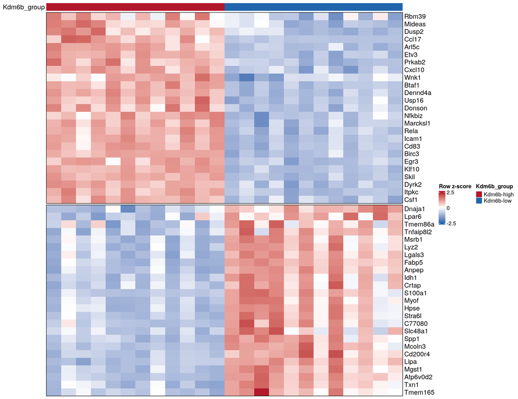

```r
heatmap_plot
```